# Challenge_4: Intro to Visulization: Univariate and Multivariate Graphs

weekly_challenges

challenge_4

Author

Jeff Scheminger

Published

October 29, 2023

**Make sure you change the author’s name in the above YAML header.**

## Setup

If you have not installed the following packages, please install them before loading them.

```r
library(tidyverse)
library(lubridate)
library(readxl)
library(haven) #for loading other datafiles (SAS, STATA, SPSS, etc.)
library(stringr) # if you have not installed this package, please install it.
library(ggplot2) # if you have not installed this package, please install it.
library(dplyr)
knitr::opts_chunk$set(echo = TRUE, warning=FALSE, message=FALSE)
```

## Challenge Overview

In this challenge, we will practice with the data we worked on in the previous challenges and the data you choose to do some simple data visualizations using the `ggplot2` package.

There will be coding components and writing components. Please read the instructions for each part and complete your challenges.

## Datasets

- Part 1 the ESS_Polity Data (created in Challenge#3) ⭐⭐
- Part 2: the Australia Data⭐⭐
- Part 3: see Part 3. Practice plotting with a dataset of your choice (25% of the total grade). For online platforms of free data, see Appendix: sources for data to be used in Part 3.

Find the `_data` folder, then read the datasets using the correct R command.

## Part 1. Univariate and Multivariate Graphs (45% of the total grade)

We have been working with these two data in the previous three challenges. Suppose we have a research project that studies European citizens’ social behaviors and public opinions, and we are interested in how the countries that respondents live in influence their behavior and opinion. In this challenge, let’s work with the combined dataset *ESS_Polity* and create some visualizations.

1. **Read the combined data you created last time. (2.5%)**

```r
#type of your code/command here.

ESS_Polity <- read_csv("_data/ESS_Polity1.csv")
View(ESS_Polity)
```

2. **Suppose we are interested in the central tendencies and distributions of the following variables. At the individual level:** *age, male, edu, income_10,* and *vote*. **At the country level**: *democ*.

   (1) Recode the “vote” column: if the value is 1, recode it as 1; if the value is 2, recode it as 0; if the value is 3, recode it as NA. **Make sure to include a sanity check for the recoded data. (2.5%)**

   ```r
   #type of your code/command here.
   # check counts of existing values
      Vote_check <- ESS_Polity %>%
   group_by(vote) %>%
   summarize(count = n())
   # result is 1 = 36804; 2 = 11432; 3 = 3688; NA = 756

   # use mutate to recode values
   ESS_Polity2 <- ESS_Polity %>%
     mutate(vote = recode(vote, `1` = 1, `2` = 0, `3` = NA_real_))

   # second check on recoded values
   Vote_check2 <- ESS_Polity2 %>%
   group_by(vote) %>%
   summarize(count = n())
     # result is 0 = 11432; 1 = 36804; NA = 4444

   # group by country to get democ numbers

   ESS_bycountry <- ESS_Polity2 %>%
     group_by(country) %>%
     slice(1)
   ```

   (2) For each of the five variables (*age, edu, income_10,* *vote,* and *democ)*, please choose an appropriate type of univariate graph to plot the central tendencies and distribution of the variables. Explain why you choose this type of graph to present a particular variable (for example: “For example, I use a histogram to plot *age* because it is a continuous numeric variable”). **(25%)**

   **(Note: You should use at least two types of univariate graphs covered in the lecture.)**

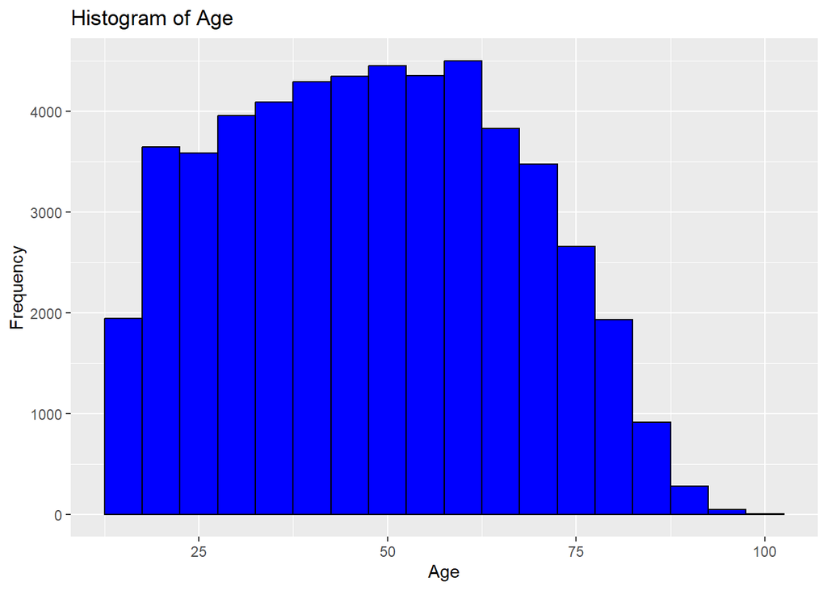

   ```r
   #type of your code/command here.
    # histogram for the "age" variable
   ggplot(ESS_Polity2, aes(x = age)) +
     geom_histogram(binwidth = 5, fill = "blue", color = "black") +
     labs(
   title = "Histogram of Age",
   x = "Age",
   y = "Frequency"
     )
   ```

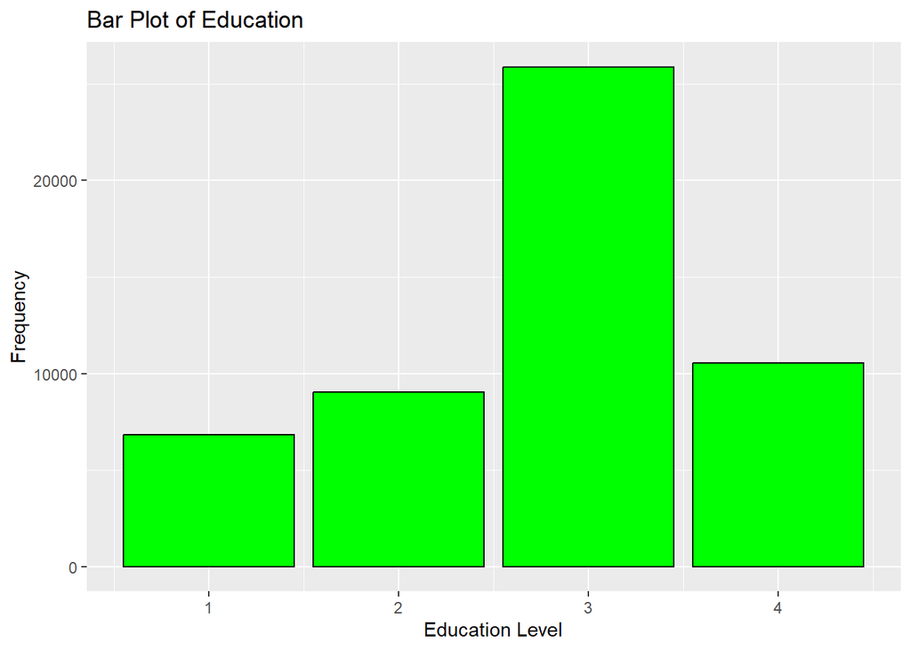

   ```r
     # bar plot for the "edu" variable
   ggplot(ESS_Polity2, aes(x = edu)) +
     geom_bar(fill = "green", color = "black") +
     labs(
   title = "Bar Plot of Education",
   x = "Education Level",
   y = "Frequency"
     )
   ```

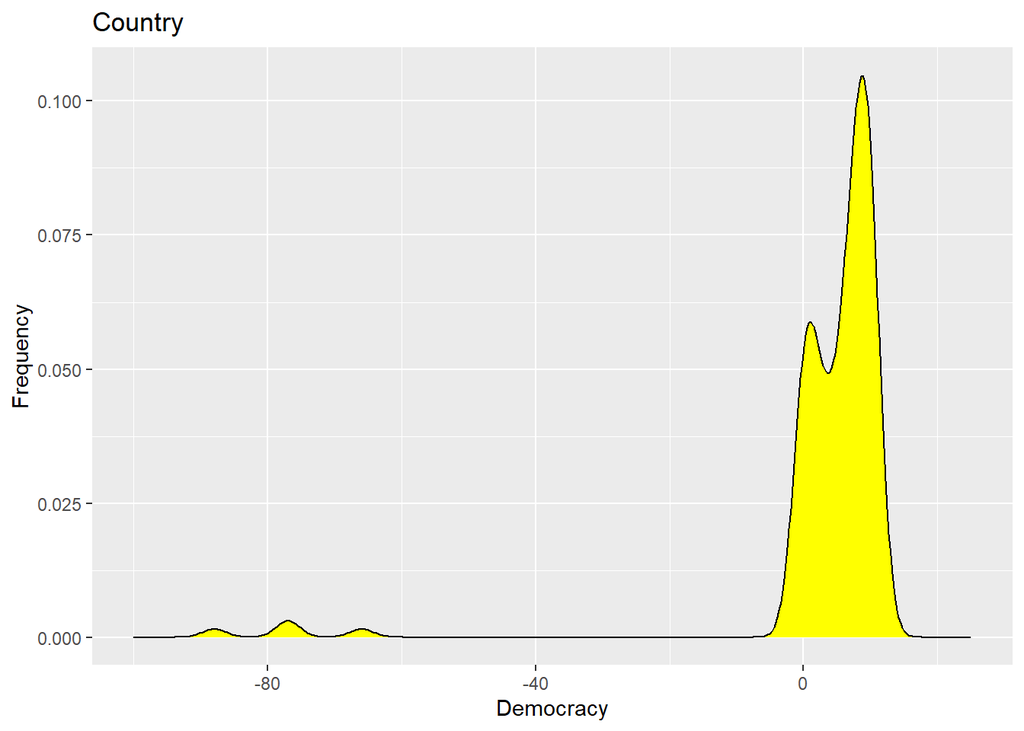

   ```r
   # density chart for "democ" variable
   #remove null values for the chart

   ggplot(ESS_bycountry, aes(x = democ)) +
     geom_density(fill = "yellow", color = "black") +
     labs(
   x = "Democracy",
   y = "Frequency",
   title = "Country"
     ) + scale_x_continuous(limits = c(-100, 25))
   ```

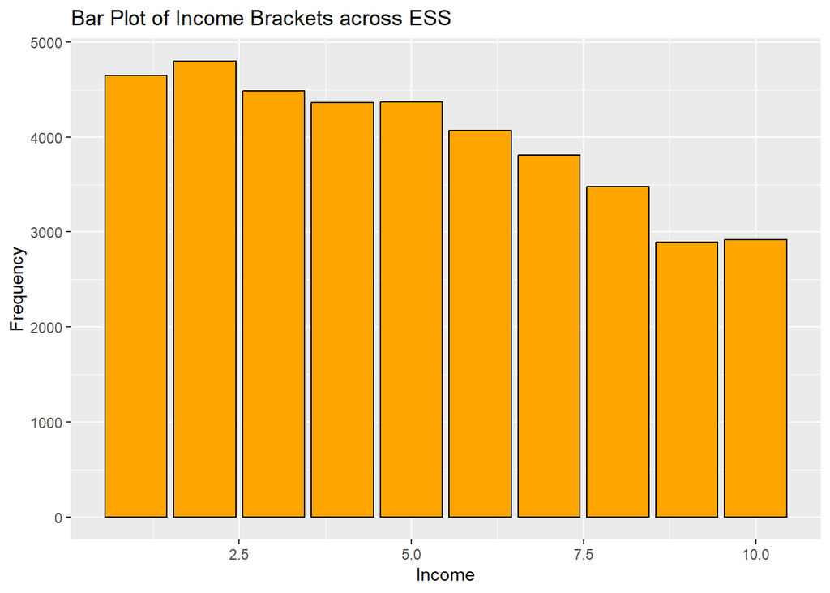

   ```r
   # tried geom_violin - ugly. Incom_10 <- ggplot(ESS_Polity2, aes(x = country, y = income_10, fill = country)) + geom_violin()

   ggplot(ESS_Polity2, aes(x = income_10)) +
     geom_bar(fill = "orange", color = "black") +
     labs(
   title = "Bar Plot of Income Brackets across ESS",
   x = "Income",
   y = "Frequency"
     )
   ```

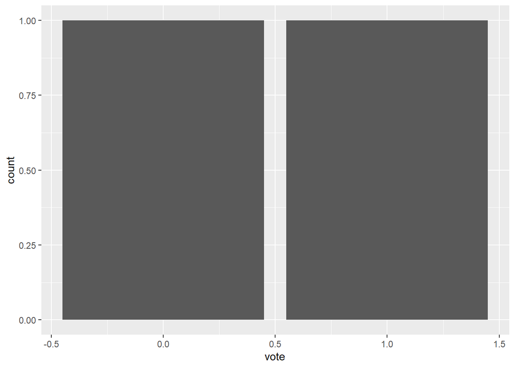

   ```r
   #  chart for "vote" variable

   ggplot(ESS_Polity2, aes(fill = vote, x = vote)) +
   geom_bar(position="fill")
   ```

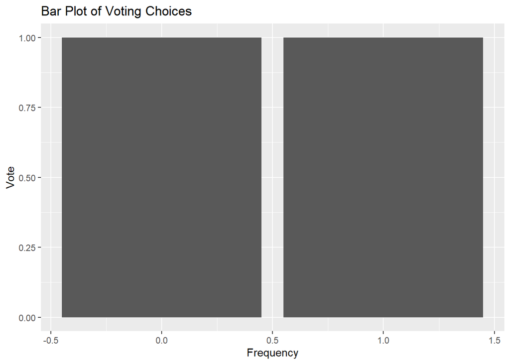

   ```r
   ggplot(ESS_Polity2, aes(x = vote)) +
     geom_bar(position = "fill") +
     labs(
   title = "Bar Plot of Voting Choices",
   x = "Frequency",
   y = "Vote"
     )
   ```

#3. **Suppose we want to test two hypotheses on the relationships of two pairs of variables**. **Please use the appropriate type of graphs we learned to visualize these two pairs of variables. Briefly describe the graph you plot, and answer: Does the graph we create from the data support the hypothesis?**

[output not shown]

## Part 2. Comparing between Partial and Whole, and among Groups (30% of the total grade)

In this part, we will use the clean version of the Australian public opinion poll on Same-Sex Marriage to generate graphs and plots. **You may need to do the data transformation or mutation needed to help graphing.**

1. Read in data. **(2.5%)**

   ```r
   #type of your code/command here.

   Austr_data3 <- read_csv("_data/australian_data - australian_data.csv")
   View(Austr_data3)
   Austr_data4 <- subset(Austr_data3, select = -c(District, Division))
   Austr_total <- Austr_data4 %>%
     summarize(Yes = sum(Yes), No = sum(No), Illegible = sum(Illegible), `No Response` = sum(`No Response`))
   #pivot long with new col names
   Austr_long <- pivot_longer(Austr_total, cols = everything(), names_to = "Response", values_to = "Total")
   ```

2. Use a barplot to graph the Australian data based on their responses: yes, no, illegible, and no response. The y-axis should be the count of responses, and each response should be represented by one individual bar (so there should be four bars). **(7.5%)**

   (you can use either geom_bar() or geom_col())

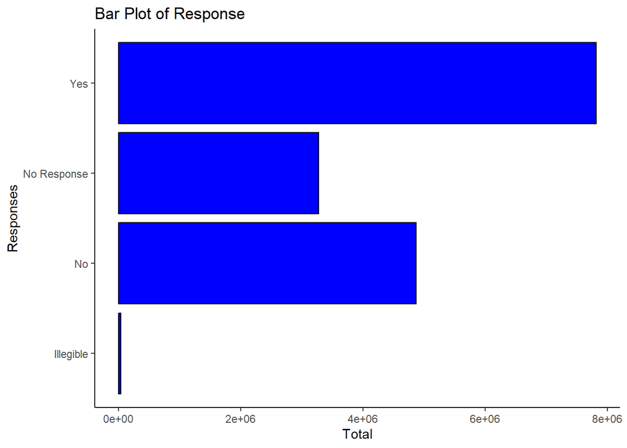

   ```r
   #type of your code/command here.

   bar_plot <- ggplot(Austr_long, aes(x = Total, y = Response)) +
     geom_bar(stat = "identity", fill = "blue", color = "black") +
     labs(
   title = "Bar Plot of Response",
   x = "Total",
   y = "Responses"
     ) +
     theme_classic()

   # Display the bar plot
   print(bar_plot)
   ```

3. The previous graph only shows the difference in amount. Let’s create a stacked-to-100% barplot to show the proportion of each of the four responses (by % of the total response). **(7.5%)**

   (you can use either geom_bar() or geom_col())

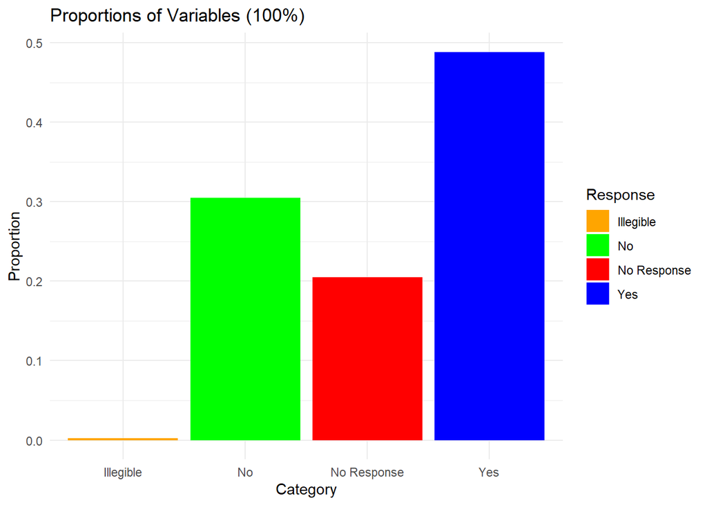

   ```r
     Austr_long$proportion <- Austr_long$Total / sum(Austr_long$Total)



   ggplot(Austr_long, aes(x = Response, y = proportion, fill = Response)) +
     geom_bar(position="stack", stat="identity") +
     labs(
   title = "Proportions of Variables (100%)",
   x = "Category",
   y = "Proportion"
     ) +
     scale_fill_manual(values = c("Yes" = "blue", "No" = "green", "Illegible" = "orange", "No Response" = "red")) +
     theme_minimal()
   ```

4. Let’s see if there’s a relationship between Division and Response - that is, are certain divisions more likely to respond one way compared to other divisions? Again, we will use barplot(s) to present the visualization. **(12.5%)**

   (you can use either geom_bar() or geom_col())

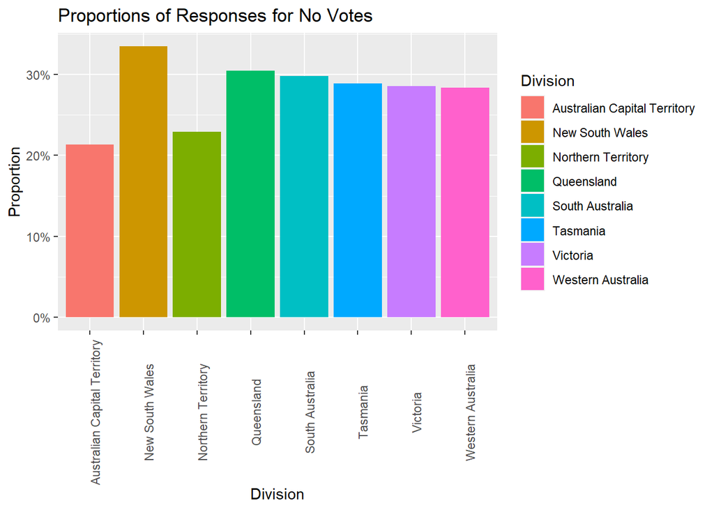

   ```r
   #type of your code/command here.
     Austr_data3 <- read_csv("_data/australian_data - australian_data.csv")

   Austr_data5 <- subset(Austr_data3, select = -c(District))

      Austr_div <- Austr_data5 %>%
     group_by(Division) %>%
     summarize(Yes = sum(Yes), No = sum(No), Illegible = sum(Illegible), `No Response` = sum(`No Response`))
   Austr_div$Division <- gsub(" Divisions", " ", as.character(Austr_div$Division))

      #get proportions for each division and variable

      Austr_div <- Austr_div %>%
     mutate(Total = Yes + No + Illegible + `No Response`)

      Austr_div$Yes_prop <- Austr_div$Yes / Austr_div$Total
      Austr_div$No_prop <- Austr_div$No / Austr_div$Total
      Austr_div$Illegible_prop <- Austr_div$Illegible /   Austr_div$Total
      Austr_div$NoResponse_prop <- Austr_div$'No Response' / Austr_div$Total

      #pivot long with new col names

      Austr_div1 <- Austr_div %>% select(-c(Yes, No, Illegible,'Total', `No Response`))


   # chart for No_prop votes
   ggplot(Austr_div1, aes(x = Division, y = No_prop, fill = Division)) +
     theme(axis.text.x=element_text(angle=90)) +
   scale_y_continuous(labels= scales::percent) +
     geom_bar(stat = "identity") +
     labs(
   title = "Proportions of Responses for No Votes",
   x = "Division",
   y = "Proportion"
     )
   ```

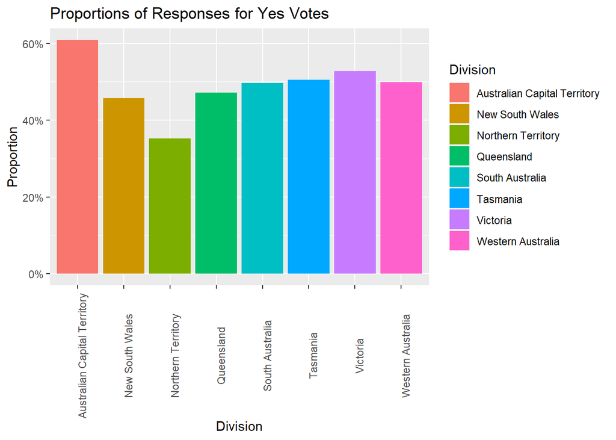

   ```r
   # chart for Yes_prop votes
   ggplot(Austr_div1, aes(x = Division, y = Yes_prop, fill = Division)) +
     theme(axis.text.x=element_text(angle=90)) +
      scale_y_continuous(labels= scales::percent) +
     geom_bar(stat = "identity") +
     labs(
   title = "Proportions of Responses for Yes Votes",
   x = "Division",
   y = "Proportion"
     )
   ```

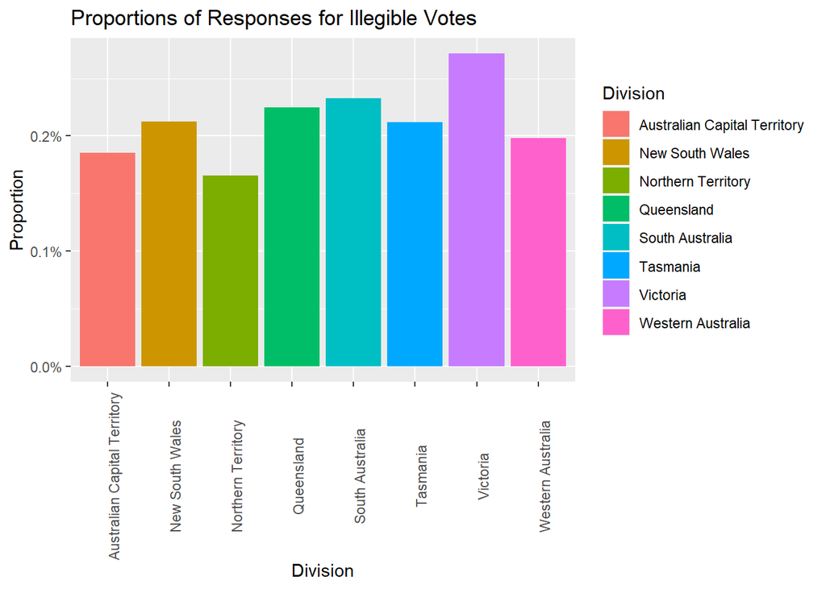

   ```r
   # chart for Illegible_prop votes
   ggplot(Austr_div1, aes(x = Division, y = Illegible_prop, fill = Division)) +
     theme(axis.text.x=element_text(angle=90)) +
     scale_y_continuous(labels= scales::percent) +
     geom_bar(stat = "identity") +
     labs(
   title = "Proportions of Responses for Illegible Votes",
   x = "Division",
   y = "Proportion"
     )
   ```

[figure not shown]

   ```r
   # chart for NoResponse_prop votes
   ggplot(Austr_div1, aes(x = Division, y = NoResponse_prop, fill = Division)) +
     theme(axis.text.x=element_text(angle=90)) +
      scale_y_continuous(labels= scales::percent) +
     geom_bar(stat = "identity") +
     labs(
   title = "Proportions of Responses for Illegible Votes",
   x = "Division",
   y = "Proportion"
     )
   ```

## Part 3. Practice plotting with a dataset of your choice (25% of the total grade)

In this part, you will choose data of your interests for graphing and plotting. This data can be tidy/ready-to-be-used or raw data that needs cleaning. If the data is very large (for example, more than 20 columns), you should definitely subset the data by selecting less than 10 variables of your interests to avoid taking too much room in your R memory.

1. Include a link to the data page (this page should include the introduction or description and the link to download this dataset). **(2%)**

COVID-19 Reporting : The COVID-19 Dashboard includes data on city/town COVID-19 activity, confirmed and probable cases of COVID-19, confirmed and probable deaths related to COVID-19, and the demographic characteristics of cases and deaths.

https://www.mass.gov/info-details/covid-19-reporting

2. Read the data you choose and briefly answer the following questions. (Optional: you may need to subset, clean, and transform the data if necessary). **(8%)**

   ```r
   #type of your code/command here.
   Covid19_maweek <- read_excel("_data/covid-19-dashboard-10-19-23.xlsx", sheet = "Weekly Cases and Deaths")
   View(Covid19_maweek)
   str(Covid19_maweek)
   ```

   ```
   tibble [191 × 10] (S3: tbl_df/tbl/data.frame)
    $ Season                       : chr [1:191] "2023-2024" "2023-2024" "2023-2024" "2023-2024" ...
    $ Week Start Date              : POSIXct[1:191], format: "2023-01-08" "2021-10-17" ...
    $ Week End Date                : POSIXct[1:191], format: "2023-01-14" "2021-10-23" ...
    $ Confirmed deaths             : num [1:191] 132 79 153 85 654 74 417 67 53 66 ...
    $ Probable deaths              : num [1:191] 47 4 15 2 23 2 47 1 9 15 ...
    $ Confirmed and probable deaths: num [1:191] 179 83 168 87 677 76 464 68 62 81 ...
    $ Confirmed cases              : num [1:191] 7075 8163 18179 9316 12145 ...
    $ Probable cases               : num [1:191] 1645 699 1009 748 30 ...
    $ Confirmed and probable cases : num [1:191] 8720 8862 19188 10064 12175 ...
    $ Last updated                 : POSIXct[1:191], format: "2023-10-19" "2023-10-19" ...
   ```

   ```r
   as_tibble(Covid19_maweek)
   ```

   | Season | Week Start Date | Week End Date | Confirmed deaths | Probable deaths | Confirmed and probable deaths | Confirmed cases | Probable cases | Confirmed and probable cases | Last updated |
   | --- | --- | --- | --- | --- | --- | --- | --- | --- | --- |
   | 2023-2024 | 2023-01-08 | 2023-01-14 | 132 | 47 | 179 | 7075 | 1645 | 8720 | 2023-10-19 |
   | 2023-2024 | 2021-10-17 | 2021-10-23 | 79 | 4 | 83 | 8163 | 699 | 8862 | 2023-10-19 |
   | 2023-2024 | 2020-11-22 | 2020-11-28 | 153 | 15 | 168 | 18179 | 1009 | 19188 | 2023-10-19 |
   | 2023-2024 | 2021-10-03 | 2021-10-09 | 85 | 2 | 87 | 9316 | 748 | 10064 | 2023-10-19 |
   | 2023-2024 | 2020-04-05 | 2020-04-11 | 654 | 23 | 677 | 12145 | 30 | 12175 | 2023-10-19 |
   | 2023-2024 | 2021-04-25 | 2021-05-01 | 74 | 2 | 76 | 7105 | 924 | 8029 | 2023-10-19 |
   | 2023-2024 | 2022-01-23 | 2022-01-29 | 417 | 47 | 464 | 38985 | 4823 | 43808 | 2023-10-19 |
   | 2023-2024 | 2021-04-18 | 2021-04-24 | 67 | 1 | 68 | 8465 | 1117 | 9582 | 2023-10-19 |
   | 2023-2024 | 2023-03-19 | 2023-03-25 | 53 | 9 | 62 | 1939 | 543 | 2482 | 2023-10-19 |
   | 2023-2024 | 2022-05-08 | 2022-05-14 | 66 | 15 | 81 | 27609 | 4166 | 31775 | 2023-10-19 |

   [output cut: 181 more lines]

   ```r
   names(Covid19_maweek)[4] ="Deaths"
   names(Covid19_maweek)[7] ="Cases"
   names(Covid19_maweek)[3] ="WeekEnd"
   Covid19_maweek$WeekEnd <- ymd(Covid19_maweek$WeekEnd)
   write_csv(Covid19_maweek, file = "_data/Covid19_maweek.csv")
   ```

   (1) what is the structure (dimension) of the data;

   (2) what is the unit of observation?

   (3) what does each column mean in this data?
3. Choose two columns/variables of your interests. Plot one univariate graph for each of the variables. **(5%)**

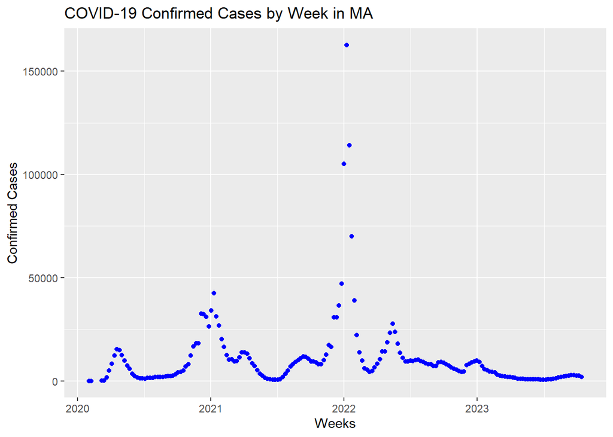

   ```r
   #type of your code/command here.
   # create scatter plot for COVID cases
   plot_cases <- ggplot(Covid19_maweek, aes(x = WeekEnd, y = Cases)) +
     geom_point(color = "blue") +
     labs(title = "COVID-19 Confirmed Cases by Week in MA", x = "Weeks", y = "Confirmed Cases")

   print(plot_cases)
   ```

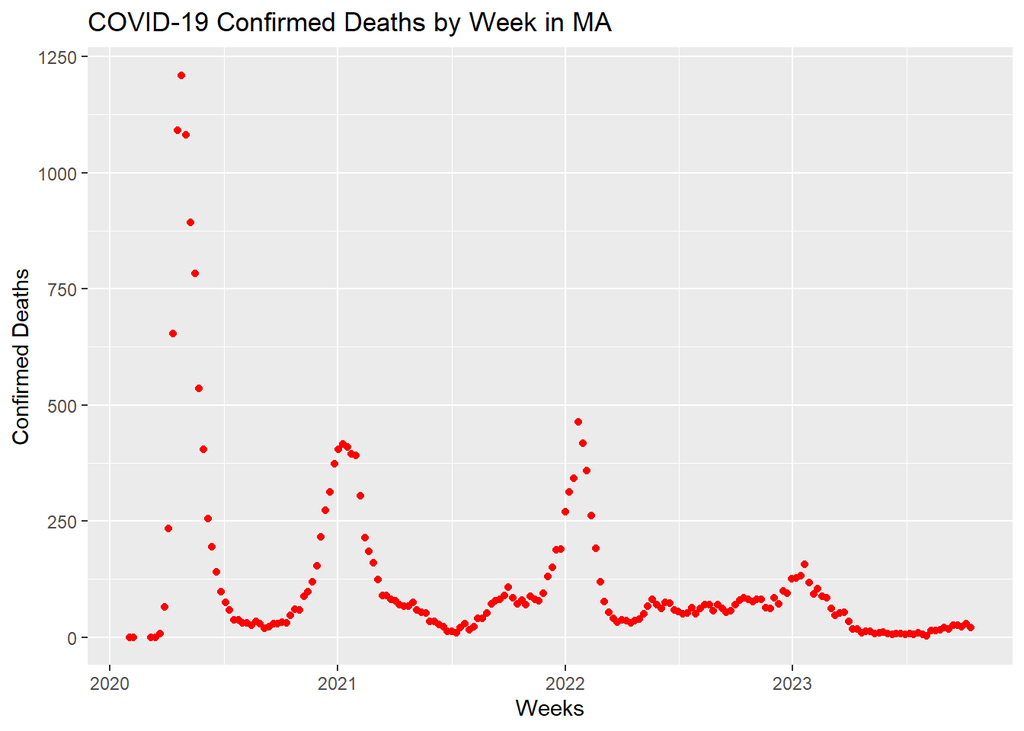

```r
# create scatter plot for COVID cases
plot_deaths <- ggplot(Covid19_maweek, aes(x = WeekEnd, y = Deaths, color = Cases)) +
  geom_point(color = "red") +
  labs(title = "COVID-19 Confirmed Deaths by Week in MA", x = "Weeks", y = "Confirmed Deaths")

print(plot_deaths)
```

4. Choose a pair of variables you suspect or hypothesize may be correlated and a graph (scatter plot or barplot) using them. Based on the visual evidence, do you see any potential correlation between the two variables **(10%)**

[figure not shown]

   ```r
   #type of your code/command here.
    plot_cases <- ggplot(Covid19_maweek, aes(x = WeekEnd)) +
     geom_line(aes(y = Cases, color = "Cases"), size = .5, linetype = "solid") +
     geom_line(aes(y = Deaths * 50, color = "Deaths"), size = .5, linetype = "solid") +
     labs(title = "COVID-19 Cases and Deaths (Scaled) Over Time in MA", x = "Date", y = "Cases") +
     scale_color_manual(name = "Metric", values = c("Cases" = "blue", "Deaths" = "red")) +
     scale_y_continuous(sec.axis = sec_axis(~./10, name = "Deaths (scaled x 50)"))

   print(plot_cases)
   ```

## Appendix: sources for data to be used in Part 3

**Here are some online sources and popular Online Dataset Hub:**

1. Many US governments (usually at the federal and state levels), bureaus, and departments have open data archives on their websites, allowing the public to access, download, and use them. Just use Google to search for them.
2. [**The Harvard Dataverse Repository**](https://dataverse.harvard.edu/) is a free data repository open to all researchers from any discipline, inside and outside the Harvard community, where you can share, archive, cite, access, and explore research data. Each individual Dataverse collection is a customizable collection of datasets (or a virtual repository) for organizing, managing, and showcasing datasets.
3. [**Inter-university Consortium for Political and Social Research (ICPSR)**](https://www.icpsr.umich.edu/web/pages/ICPSR/index.html) of the University of Michigan-Ann Arbor provides leadership and training in data access, curation, and methods of analysis for the social science research community.
4. **UN: https://data.un.org/**
5. [**OECD Data**](https://data.oecd.org/): economic and development data of the most developed countries in the world.
6. The upper five sources are mainly for social science data; **there is another very big community and open data archives for machine-learning and data science: [Kaggle](https://www.kaggle.com/datasets).**